# UNICEF Report: Life Expectancy and Global Development

Author

Jahnavi Dutt M

# Introduction

Children and adolescents experience very different life outcomes depending on the country in which they live. This analysis involves UNICEF datasets and aims at revealing the diversity in development conditions of countries worldwide and uncovering correlations between the two aspects.

The data includes UNICEF indicator dataset and socio-economic metadata. There are three research questions guiding the report:

1. Which are the best-performing countries in terms of life expectancy?
2. What is the strength of connection between life expectancy and economic development?
3. What are the patterns worldwide and how do they differ between countries and years?

The results indicate that the life expectancy rates differ from country to country and cannot be considered equally spread worldwide. Economic conditions play an important role in explaining the difference, yet region-specific peculiarities can be observed.

# Data and Methods

The analysis uses two types of data:

- **UNICEF indicator data**, used to capture the selected adolescent-related indicator
- **Socio-economic metadata**, used to examine population, GDP per capita, and life expectancy

The data were analyzed with **Polars** through filtering, selecting, aggregating, and joining. Plots were generated with **plotnine** based on the grammar of graphics concept. The map of the world was produced by combining country-specific values with the geographical shape file based on the ISO country codes.

# Countries with the Highest Life Expectancy

The first graph focuses on the countries that have the highest life expectancy for the latest year reported. The findings indicate that there are countries like Monaco, San Marino, and Japan that have exceptionally high figures. This can be attributed to the fact that these nations possess efficient medical facilities, a high standard of living, and social stability over time.

The first graph gives an easy way of comparing the leading nations with regard to their health status. Nevertheless, the findings indicate that good health statistics cannot be attributed to randomness alone.

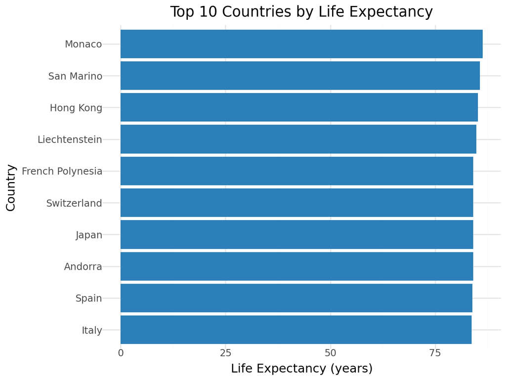

Figure 1: Countries with the highest life expectancy in the most recent year.

# Economic Development and Life Expectancy

The scatter plot focuses on the correlation between GDP per capita and the life expectancy rate. It can be noticed that there is a strong correlation between these two elements since richer nations generally have a higher life expectancy rate.

By using logarithms on the GDP per capita axis, the data will become easier to analyze since the very high-income economies will affect the graph less visually. Even if the correlation is evident, there is some variance among the observations that is due to other factors apart from income level, such as health policies and education.

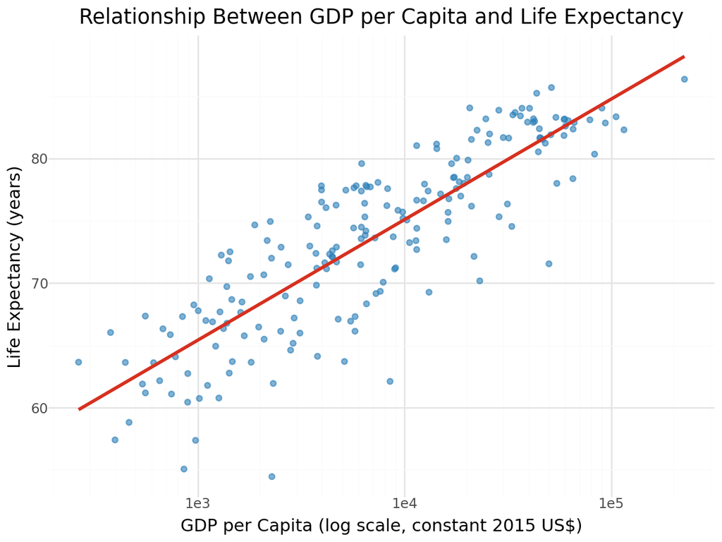

Figure 2: Relationship between GDP per capita and life expectancy, showing a strong positive association across countries.

# Global Distribution of the UNICEF Indicator

This is the map of the world that depicts the geographical pattern of the chosen indicator from UNICEF in the most recently available year. The data had been cleaned and aggregated such that there was only one figure per observation, after which they were joined to the geographic boundaries using the ISO code.

From the map above, it is evident that geographical inequalities exist. There are areas with far much higher figures compared to other areas. From this, it is clear that adolescent issues are determined by many other factors other than the numerical ones.

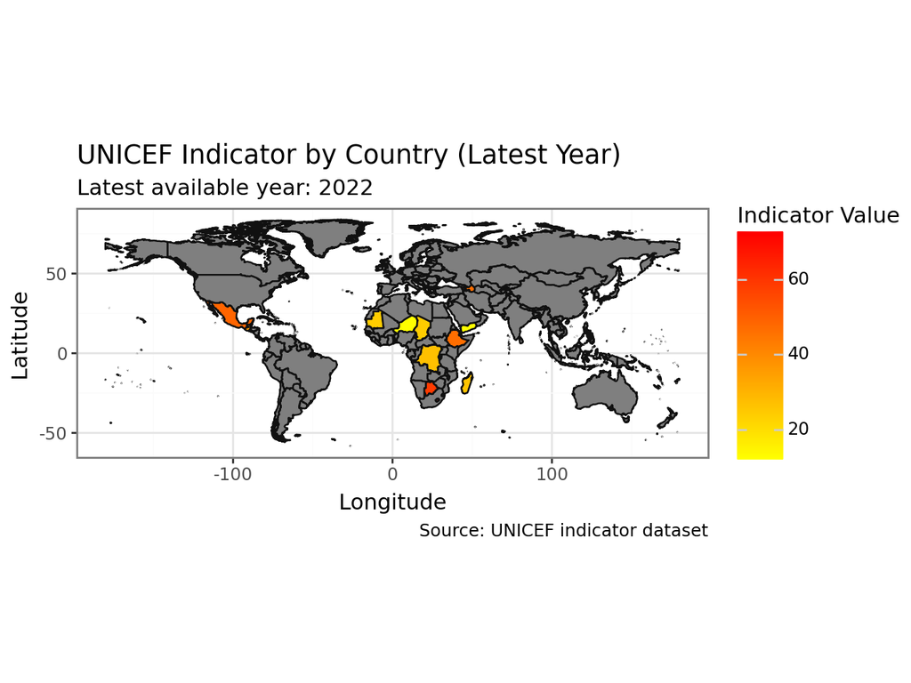

Figure 3: Global distribution of the selected UNICEF indicator in the most recent year.

# Change Over Time

Such steady improvement is expected since it coincides with advancements made in terms of health care delivery, sanitation, nutrition, and health care policies in general. Still, as was seen from previous graphs, such progress has been uneven between different countries.

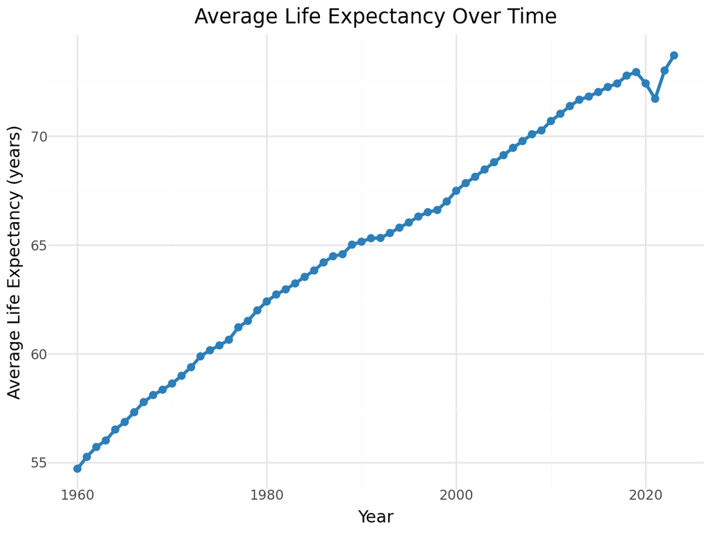

Figure 4: Global average life expectancy over time, showing a steady long-term increase.

# Conclusion

The research indicates that there is still a strong relationship between life expectancy and development factors. The more developed country tends to have better results concerning the health status of its population, the map of the world also shows that these inequalities exist. Moreover, the average life expectancy is increasing, although not equally for all countries.

For UNICEF, these results matter since the lives of children and teenagers depend on the overall development environment where they live. Thus, decreasing these inequalities in health conditions is essential for children and adolescents’ better future.

Overall, the conclusions drawn from the data indicate that although global health indicators tend to improve over time, there are still substantial inequalities among countries caused by their economic development level.